# **Loan Approval Prediction**

Authors:Abhilasha Singh, Aswin Balaji Thippa Ramesh, Lixing Pan

2024-12-13

# **Introduction**

This project aims to analyze how various applicant and loan-related factors influence loan approval decisions. We will explore applicant profiles, focusing on key variables such as credit score, annual income, employment status, debt-to-income ratio,along with loan-specific details like interest rate, loan amount, and risk score. By identifying patterns and correlations within a dataset of 20,000 records, which includes demographic information, credit history, and income levels, we aim to gain valuable insights. The dataset serves two primary purposes: Risk Score Regression, which predicts an individual’s likelihood of loan default or financial instability, and Binary Classification, which determines whether an applicant is likely to be approved or denied for a loan. While both objectives are important, our primary focus will be on the binary classification for loan approval prediction.

# **Data Overview and Limitations**

## Dataset Description:

The dataset used for this analysis is sourced from the Kaggle. We have synthetic dataset comprising of 20,000 records of personal and financial data, designed to facilitate the development of predictive models for risk assessment.The following table provides definitions for each variable in the dataset:

| **Variable** | **Definition** |
| --- | --- |
| ApplicationDate | The date when the loan application was submitted. |
| Age | The age of the applicant. |
| AnnualIncome | The yearly income of the applicant. |
| CreditScore | The creditworthiness score of the applicant. |
| EmploymentStatus | The applicant’s current employment situation. |
| EducationLevel | The highest level of education attained by the applicant. |
| Experience | The work experience of the applicant. |
| LoanAmount | The amount of loan requested by the applicant. |
| LoanDuration | The repayment period for the loan. |
| MaritalStatus | The marital status of the applicant. |
| NumberOfDependents | The number of dependents the applicant is financially responsible for. |
| HomeOwnershipStatus | The type of homeownership (e.g., owned, rented) of the applicant. |
| MonthlyDebtPayments | The monthly amount the applicant needs to pay for existing debts. |
| CreditCardUtilizationRate | The percentage of the applicant’s credit card limit that is being used. |
| NumberOfOpenCreditLines | The number of active credit lines the applicant holds. |
| NumberOfCreditInquiries | The total number of credit inquiries made by the applicant. |
| DebtToIncomeRatio | The ratio of the applicant’s debt to their income. |
| BankruptcyHistory | The history of bankruptcy filings by the applicant. |
| LoanPurpose | The reason the applicant is applying for the loan. |
| PreviousLoanDefaults | Whether the applicant has defaulted on previous loans. |
| PaymentHistory | The applicant’s past behavior in making payments. |
| LengthOfCreditHistory | The duration of the applicant’s credit history. |
| SavingsAccountBalance | The balance in the applicant’s savings account. |
| CheckingAccountBalance | The balance in the applicant’s checking account. |
| TotalAssets | The total value of the applicant’s assets. |
| TotalLiabilities | The total value of the applicant’s liabilities. |
| MonthlyIncome | The applicant’s monthly income. |
| UtilityBillsPaymentHistory | The applicant’s history of utility bill payments. |
| JobTenure | The length of time the applicant has been employed at their current job. |
| NetWorth | The applicant’s total financial worth. |
| BaseInterestRate | The starting interest rate applied to the loan. |
| InterestRate | The actual interest rate applied to the loan. |
| MonthlyLoanPayment | The monthly payment amount for the loan. |
| TotalDebtToIncomeRatio | The total debt relative to the applicant’s income. |
| LoanApproved | The approval status of the loan (whether it is approved or denied). |
| RiskScore | The risk assessment score assigned to the applicant. |

## Summary of the dataset:

```r
df=read.csv("Loan.csv")
str(df)
```

```
## 'data.frame':    20000 obs. of  36 variables:
##  $ ApplicationDate           : chr  "2018-01-01" "2018-01-02" "2018-01-03" "2018-01-04" ...
##  $ Age                       : int  45 38 47 58 37 37 58 49 34 46 ...
##  $ AnnualIncome              : int  39948 39709 40724 69084 103264 178310 51250 97345 116841 40615 ...
##  $ CreditScore               : int  617 628 570 545 594 626 564 516 603 612 ...
##  $ EmploymentStatus          : chr  "Employed" "Employed" "Employed" "Employed" ...
##  $ EducationLevel            : chr  "Master" "Associate" "Bachelor" "High School" ...
##  $ Experience                : int  22 15 26 34 17 16 39 23 12 19 ...
##  $ LoanAmount                : int  13152 26045 17627 37898 9184 15433 12741 19634 55353 25443 ...
##  $ LoanDuration              : int  48 48 36 96 36 72 48 12 60 12 ...
##  $ MaritalStatus             : chr  "Married" "Single" "Married" "Single" ...
##  $ NumberOfDependents        : int  2 1 2 1 1 0 0 5 5 4 ...
##  $ HomeOwnershipStatus       : chr  "Own" "Mortgage" "Rent" "Mortgage" ...
##  $ MonthlyDebtPayments       : int  183 496 902 755 274 732 337 288 638 704 ...
##  $ CreditCardUtilizationRate : num  0.3544 0.0878 0.1374 0.2676 0.3205 ...
```

[output cut: 22 more lines]

# **Smart Questions**

Our primary focus will be on the binary classification for loan approval prediction,which determines which variables are is likely to contibute for loan approved.

1. What are the financial and demographic profiles of high-risk versus low-risk applicants for loan approval?
2. How does debt-to-income ratio impact loan approval, interest rates, and risk scores?
3. What is the relationship between loan purpose and repayment behavior, and how does it affect risk?
4. How does credit score impact interest rates, loan approval, and loan amount?
5. What are the strongest predictors of loan approval or rejection?

# **Data Cleaning**

## Handling Missing Values:

Missing values can compromise the integrity of the dataset.If certain features are missing, the model might not learn properly, leading to suboptimal performance.

```r
# Check for missing values in every column
missing_summary <- colSums(is.na(df))

# Check if there are no missing values
if (all(missing_summary == 0)) {
  cat("There are no missing values present in the data.\n")

} else {
  cat("Missing values are present in the data. Please handle them before proceeding.\n")
}
```

```
## There are no missing values present in the data.
```

**Key Observations:**  
The dataset is complete, with no missing entries in any of the variables. This ensures that we can perform our analysis without the need for imputation or removal of any data points, preserving the integrity of the dataset.

## Handling Duplicate Values:

Duplicates can bias statistical analysis and lead to overemphasis on certain data points.Removing duplicates improves computational efficiency and makes algorithms run faster.

```r
# Check for duplicate rows
duplicates_count <- sum(duplicated(df))  # Count of duplicate rows

# Display message based on the presence of duplicate rows
if (duplicates_count == 0) {
  cat("There are no duplicate rows present in the data.\n")
} else {
  cat("Total duplicate rows:", duplicates_count, "\n")
  # Optionally display duplicate rows
  print(df[duplicated(df), ])
}
```

```
## There are no duplicate rows present in the data.
```

**Key Observations:**  
There are no redundant records in the dataset, meaning each observation is unique. This is crucial to ensure that the analysis is not skewed by redundant data, leading to accurate and reliable results.

## Handling Data Type:

To analyze the dataset and extract insights, certain categorical data needed to be converted into factors.

The first 2 rows from the data frame:

```r
#Converting relevvant variables as factor
df$EmploymentStatus=as.factor(df$EmploymentStatus)
df$EducationLevel=as.factor(df$EducationLevel)
df$MaritalStatus=as.factor(df$MaritalStatus)
df$HomeOwnershipStatus=as.factor(df$HomeOwnershipStatus)
df$LoanPurpose=as.factor(df$LoanPurpose)
df$BankruptcyHistory <- as.factor(df$BankruptcyHistory)

# Categorize Risk into Low, Medium, and High groups based on quantiles
df$RiskGroup <- cut(
  df$RiskScore,
  breaks = quantile(df$RiskScore, probs = c(0, 0.4, 1), na.rm = TRUE),
  labels = c("Low Risk", "High Risk"),
  include.lowest = TRUE
)

# Convert RiskGroup to a factor
df$RiskGroup <- factor(df$RiskGroup, levels = c("Low Risk", "High Risk"))

head(df, 2)
```

```
##   ApplicationDate Age AnnualIncome CreditScore EmploymentStatus EducationLevel
## 1      2018-01-01  45        39948         617         Employed         Master
## 2      2018-01-02  38        39709         628         Employed      Associate
##   Experience LoanAmount LoanDuration MaritalStatus NumberOfDependents
## 1         22      13152           48       Married                  2
## 2         15      26045           48        Single                  1
##   HomeOwnershipStatus MonthlyDebtPayments CreditCardUtilizationRate
## 1                 Own                 183                    0.3544
## 2            Mortgage                 496                    0.0878
##   NumberOfOpenCreditLines NumberOfCreditInquiries DebtToIncomeRatio
## 1                       1                       2             0.358
## 2                       5                       3             0.330
##   BankruptcyHistory        LoanPurpose PreviousLoanDefaults PaymentHistory
## 1                 0               Home                    0             29
## 2                 0 Debt Consolidation                    0             21
##   LengthOfCreditHistory SavingsAccountBalance CheckingAccountBalance
## 1                     9                  7632                   1202
## 2                     9                  4627                   3460
##   TotalAssets TotalLiabilities MonthlyIncome UtilityBillsPaymentHistory
## 1      146111            19183          3329                      0.725
## 2       53204             9595          3309                      0.935
##   JobTenure NetWorth BaseInterestRate InterestRate MonthlyLoanPayment
## 1        11   126928            0.200        0.228                420
## 2         3    43609            0.207        0.201                794
##   TotalDebtToIncomeRatio LoanApproved RiskScore RiskGroup
## 1                  0.181            0        49  Low Risk
## 2                  0.390            0        52 High Risk
```

**Adding Riskgroup Variable:**  
The purpose of categorizing the RiskScore into “Low Risk” and “High Risk” groups is likely to simplify risk assessment and decision-making in the context of loan approval or financial analysis.Low Risk category includes all RiskScore values from the minimum to the 40th percentile i.e.(0-40%).High Risk category includes all RiskScore values from the 40th percentile to the maximum value (i.e., 40%-100%).

## Handling Outliers:

Handling outliers is essential to ensure model accuracy, prevent overfitting or underfitting, and maintain reliable statistical analysis. Among the 36 variables, credit score stands out as a key predictor, which is why we have selected it for the analysis.

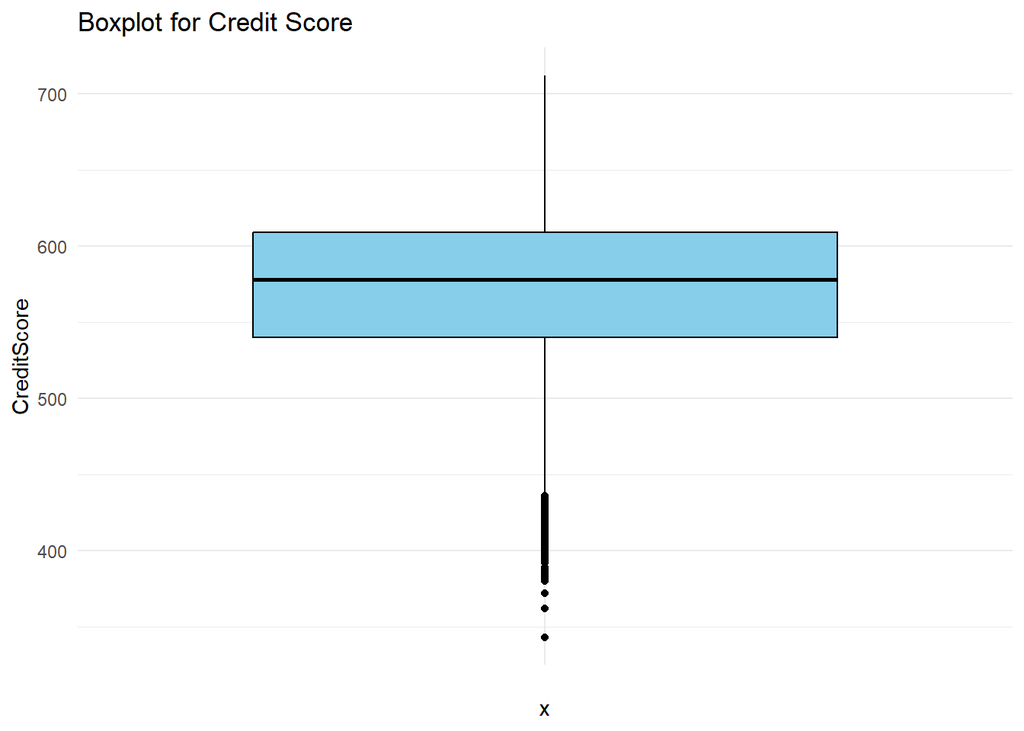

```r
# Boxplot for detecting outliers in numerical features (example for AnnualIncome)
ggplot(df, aes(x = "", y = CreditScore)) +
  geom_boxplot(fill = "skyblue", color = "black") +
  theme_minimal() +
  labs(title = "Boxplot for Credit Score")
```

**Key Observations:**  
In our dataset, outliers should be retained because they represent significant and varied applicant behaviors, which are essential for accurately capturing the full spectrum of financial risk. This helps improve the loan approval process by ensuring that analysis and models take into account all potential risk factors. For instance, the credit score is a key predictor. Outliers in credit scores, particularly extreme low values, are valuable data points. These outliers are crucial as they offer insights into the lower end of the creditworthiness spectrum, enabling financial institutions to better assess the risk associated with loan applicants. Low credit scores indicate high risk and a reduced chance of loan approval. Instead of removing these outliers, they should be retained, as they play a vital role in making informed and accurate credit decisions.

# **Exploratory Analysis**

## Univariate Analysis:

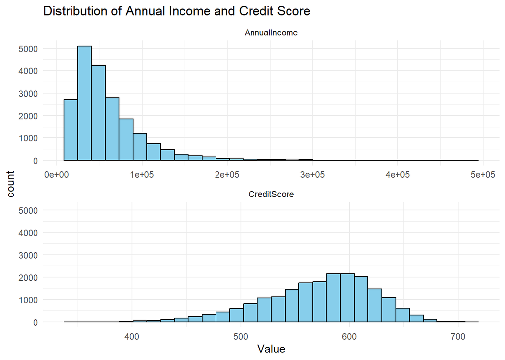

```r
# Convert ApplicationDate to Date type
df$ApplicationDate <- as.Date(df$ApplicationDate, format="%Y-%m-%d")  # Adjust format if needed

# Handle missing values by imputing or removing (choose according to your dataset)
df <- na.omit(df)  # For simplicity, we omit rows with missing values

# 3. Visualizing numerical variables
# Plot distribution of numerical features
numerical_features <- c("Age", "AnnualIncome", "CreditScore", "Experience",
                        "LoanAmount", "LoanDuration", "MonthlyDebtPayments",
                        "CreditCardUtilizationRate", "NumberOfOpenCreditLines",
                        "NumberOfCreditInquiries", "DebtToIncomeRatio",
                        "TotalLiabilities", "MonthlyIncome", "NetWorth",
                        "BaseInterestRate", "InterestRate", "MonthlyLoanPayment",
                        "TotalDebtToIncomeRatio", "RiskScore")

# Histogram for all numerical variables
selected_features <- c("AnnualIncome", "CreditScore")
df %>%
  select(selected_features) %>%
  gather(key = "Variable", value = "Value") %>%
  ggplot(aes(x = Value)) +
  geom_histogram(bins = 30, fill = "skyblue", color = "black") +
  facet_wrap(~Variable, scales = "free_x", ncol = 1) +  # Display variables in separate rows
  theme_minimal() +
  labs(title = "Distribution of Annual Income and Credit Score")
```

**Key Observations:**  
The data shows a mix of distributions across variables—some, like Annual Income, are skewed due to the nature of the variable (e.g., income disparities), while others, like Credit Score, are more normally distributed. This variation reflects the inherent characteristics of each feature.

## Bivariate Analysis:

Bivariate analysis is essential for understanding the relationship between two variables, aiding in feature selection, model development, and hypothesis formulation. Since our target variable is Loan Approval, we focused on exploring the relationship between Loan Approval and Risk Score to better inform our analysis.

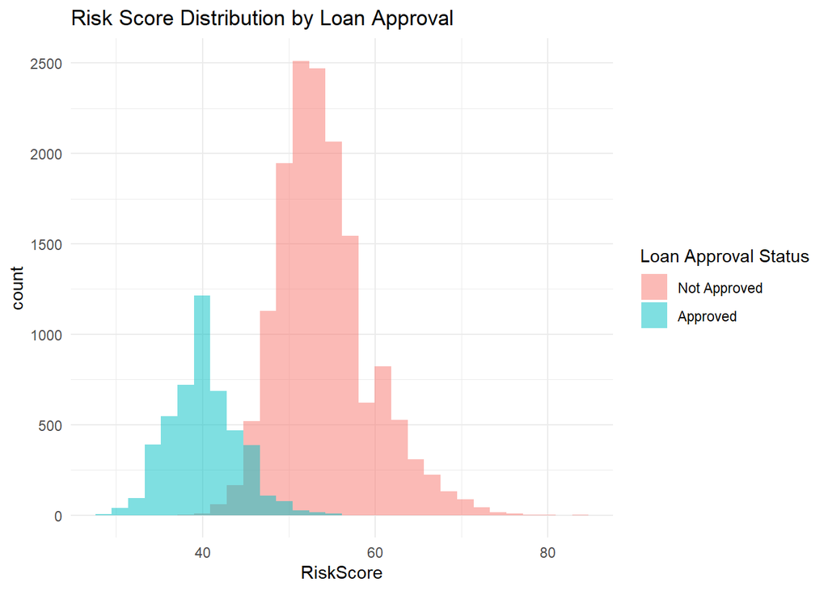

```r
#Checking RiskScore distribution and its relationship with LoanApproval
ggplot(df, aes(x = RiskScore, fill = factor(LoanApproved, labels = c("Not Approved", "Approved")))) +
  geom_histogram(position = "identity", alpha = 0.5, bins = 30) +
  theme_minimal() +
  labs(title = "Risk Score Distribution by Loan Approval", fill = "Loan Approval Status")
```

## Multivariate Analysis

Analyzing multiple variables simultaneously through multivariate analysis enhances the accuracy of models, uncovers hidden patterns, and supports more informed decision-making. In this context, we are examining the relationship between our target variable (Loan Approval) and other relevant variables, such as Risk Score, Annual Income, Debt-to-Income Ratio, and Age. By understanding how these factors interact and contribute together to loan approval decisions, we can improve the predictive power and reliability of our model.

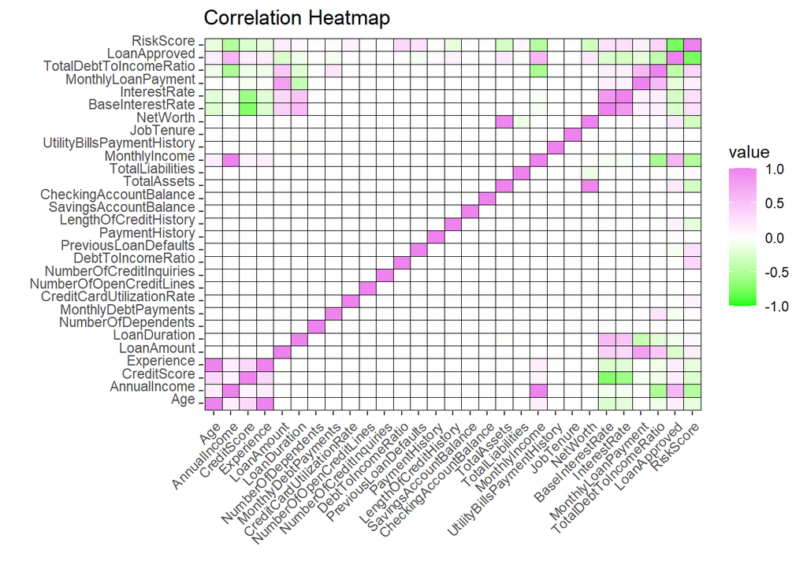

```r
#correlation matrix
cor_matrix <- cor(df[, sapply(df, is.numeric)])

# Melt the correlation matrix for plotting
melted_cor_matrix <- melt(cor_matrix)

# Correlation heatmap
ggplot(melted_cor_matrix, aes(Var1, Var2, fill = value)) +
  geom_tile(color = "black") +
  scale_fill_gradient2(low = "green", high = "violet", mid = "white", midpoint = 0, limit = c(-1, 1)) +
  labs(title = "Correlation Heatmap", x = "", y = "") +
  theme(axis.text.x = element_text(angle = 45, vjust = 1, hjust=1),axis.text.y = element_text(vjust = 0, hjust=1))
```

## Multicollinearity

```r
# Function to identify and drop multicollinear columns
drop_multicollinear <- function(df, threshold = 0.85) {
  # Select only numeric columns
  numeric_data <- df %>% select_if(is.numeric)

  # Compute correlation matrix
  correlation_matrix <- cor(numeric_data, use = "pairwise.complete.obs")

  # Find highly correlated features
  high_corr_indices <- findCorrelation(correlation_matrix, cutoff = threshold)
  columns_to_drop <- colnames(numeric_data)[high_corr_indices]

  print(paste("Dropping multicollinear columns using correlation matrix:", paste(columns_to_drop, collapse = ", ")))

  # Drop multicollinear columns
  df <- df %>% select(-all_of(columns_to_drop))
  return(df)
}

# Apply the function
df <- drop_multicollinear(df, threshold = 0.85)
```

```
## [1] "Dropping multicollinear columns using correlation matrix: MonthlyIncome, Experience, NetWorth"
```

```r
df <- df %>% select(-TotalDebtToIncomeRatio)
```

In the correlation matrix as well we observed that:

MonthlyIncome can be derived by dividing Annual Income by 12, so it was deemed redundant. Experience can be approximated using the Age variable, as experience often correlates with age. NetWorth can be calculated from the total Assets column, making it unnecessary to include both.

By dropping these columns, we reduce multicollinearity and simplify the model, while still retaining important information.

# **Smart Questions Analysis**

## Question 1.

### What are the financial and demographic profiles of high-risk versus low-risk applicants for loan approval?

High-risk loan applicants often have lower or inconsistent income, short or unstable employment histories, limited assets, and may be younger or older with less financial stability. They may also be unmarried or in non-stable marital situations, which can affect financial security. In contrast, low-risk applicants typically have higher, consistent income, stable, long-term employment, significant assets, and are often middle-aged with more financial experience. They may also have a stable marital status, contributing to overall financial stability, making them more likely to repay loans.

Initially, we will examine the role of age in loan approval decisions using violin plot to understand how it influences the likelihood of approval for high-risk and low-risk applicants.

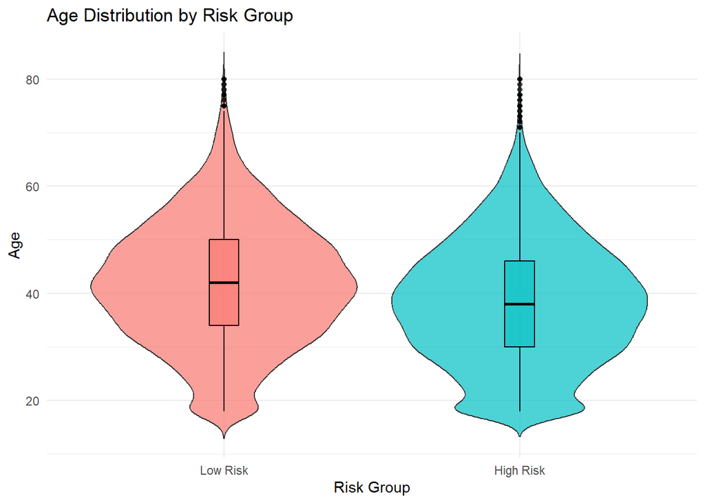

```r
# Age: Violin Plot
ggplot(df, aes(x = RiskGroup, y = Age, fill = RiskGroup)) +
  geom_violin(trim = FALSE, alpha = 0.7) +
  geom_boxplot(width = 0.1, position = position_dodge(0.9), color = "black", alpha = 0.6) +
  labs(title = "Age Distribution by Risk Group", x = "Risk Group", y = "Age") +
  theme_minimal() +
  theme(legend.position = "none")
```

```r
cat("Conclusion: Age is almost uniformly distributed among both risk groups.\n")
```

```
## Conclusion: Age is almost uniformly distributed among both risk groups.
```

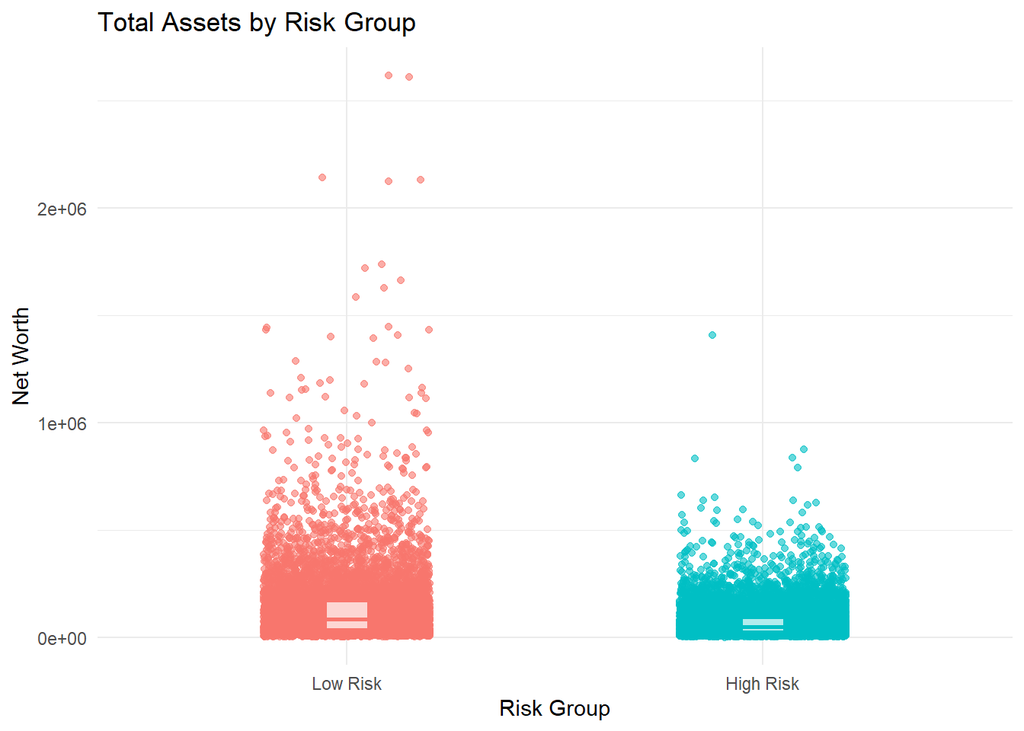

```r
# Total Assets: Scatter Plot with Smoothing
ggplot(df, aes(x = RiskGroup, y = TotalAssets, color = RiskGroup)) +
  geom_jitter(width = 0.2, alpha = 0.6) +
  geom_boxplot(width = 0.1, alpha = 0.7, outlier.shape = NA) +
  labs(title = "Total Assets by Risk Group", x = "Risk Group", y = "Net Worth") +
  theme_minimal() +
  theme(legend.position = "none")
```

```r
cat("Conclusion: Low-risk applicants have significantly higher Total Assets compared to high-risk applicants, with greater variability in the low-risk group.\n")
```

```
## Conclusion: Low-risk applicants have significantly higher Total Assets compared to high-risk applicants, with greater variability in the low-risk group.
```

Now, we will use a density plot to visualize the distribution of Annual Income across different Risk Groups (Low Risk and High Risk). This will help us understand how income levels vary between these groups and whether income plays a significant role in determining an applicant’s risk profile

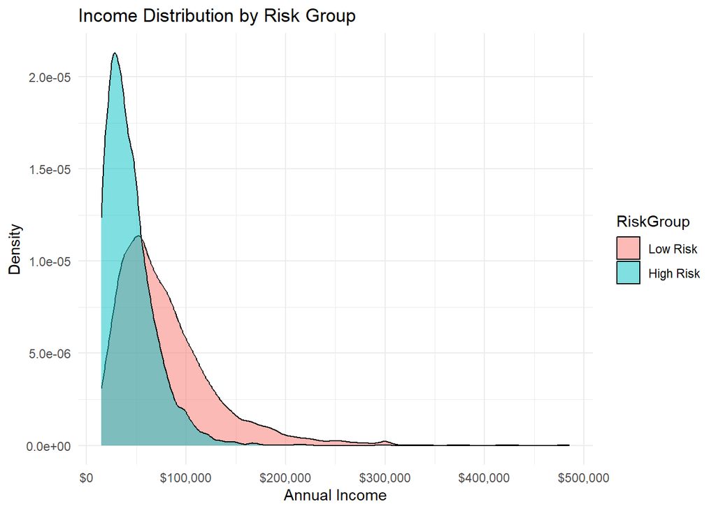

```r
# Income: Density Plot
ggplot(df, aes(x = AnnualIncome, fill = RiskGroup)) +
  geom_density(alpha = 0.5) +
  labs(title = "Income Distribution by Risk Group", x = "Annual Income", y = "Density") +
  theme_minimal() +
  scale_x_continuous(labels = scales::dollar_format())
```

```r
cat("Conclusion: Low-risk applicants have higher & wider income. While high-risk applicants, have lower incomes.\n")
```

```
## Conclusion: Low-risk applicants have higher & wider income. While high-risk applicants, have lower incomes.
```

Next, we will analyze the effect of Marital Status on loan approval by using a grouped bar chart. This visualization will allow us to compare approval rates across different marital status categories (e.g., Single, Married) and observe any significant trends or patterns.

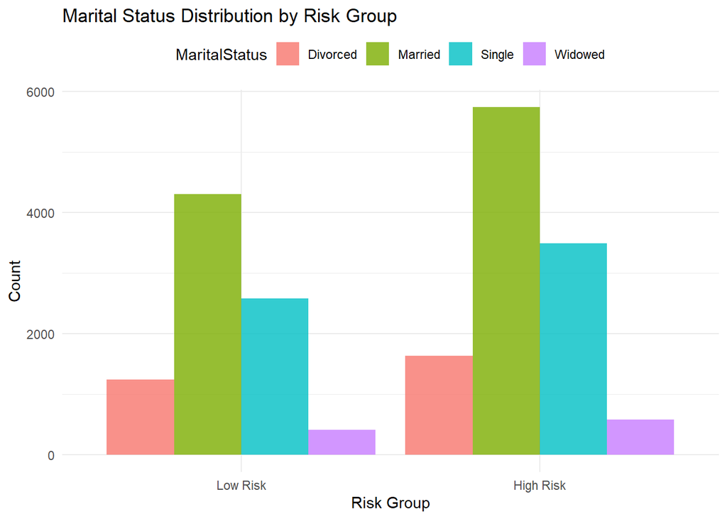

```r
## Marital Status: Grouped Bar Chart
ggplot(df, aes(x = RiskGroup, fill = MaritalStatus)) +
  geom_bar(position = "dodge", alpha = 0.8) +
  labs(title = "Marital Status Distribution by Risk Group", x = "Risk Group", y = "Count") +
  theme_minimal() +
  theme(legend.position = "top")
```

```r
cat("Conclusion: High-risk applicants have higher proportions of all the marital status,suggesting no significance.\n")
```

```
## Conclusion: High-risk applicants have higher proportions of all the marital status,suggesting no significance.
```

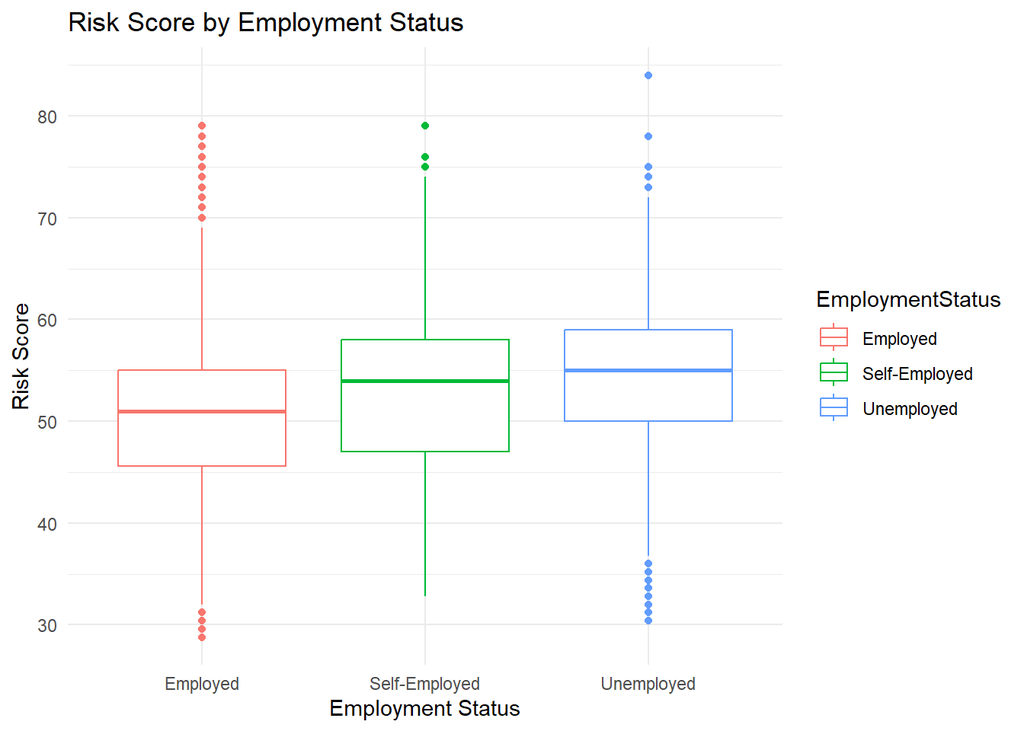

```r
# Plot RiskScore vs Employment Status (categorical)
ggplot(df, aes(x = EmploymentStatus, y = RiskScore, color = EmploymentStatus)) +
  geom_boxplot() +
  labs(title = "Risk Score by Employment Status", x = "Employment Status", y = "Risk Score") +
  theme_minimal()
```

```r
cat("Conclusion: Applicants who are employed have lower risk score. While unemployed and self-employed  applications have slightly higher risk score.\n")
```

```
## Conclusion: Applicants who are employed have lower risk score. While unemployed and self-employed  applications have slightly higher risk score.
```

**Key Observations:**

The age distribution is nearly uniform across both risk groups, showing no significant differentiation in loan approval based on age. Financially, low-risk applicants, who are more likely to receive loan approval, possess significantly higher total assets with greater variability compared to high-risk applicants. Similarly, low-risk applicants demonstrate higher and more varied income levels, aligning with their higher approval rates, while high-risk applicants generally have lower incomes and are less likely to be approved. Marital status does not appear to significantly influence risk or approval rates, as high-risk applicants are proportionately distributed across all marital categories. Employment status, however, is a notable factor employed individuals exhibit lower risk scores and higher approval rates, while unemployed and self-employed applicants show slightly higher risk scores, reducing their chances of approval.

## Question 2.

### How does debt-to-income ratio impact loan approval, interest rates, and risk scores?

Initially, we will start the analysis with the debt-to-income (DTI) ratio’s impact on loan approval.

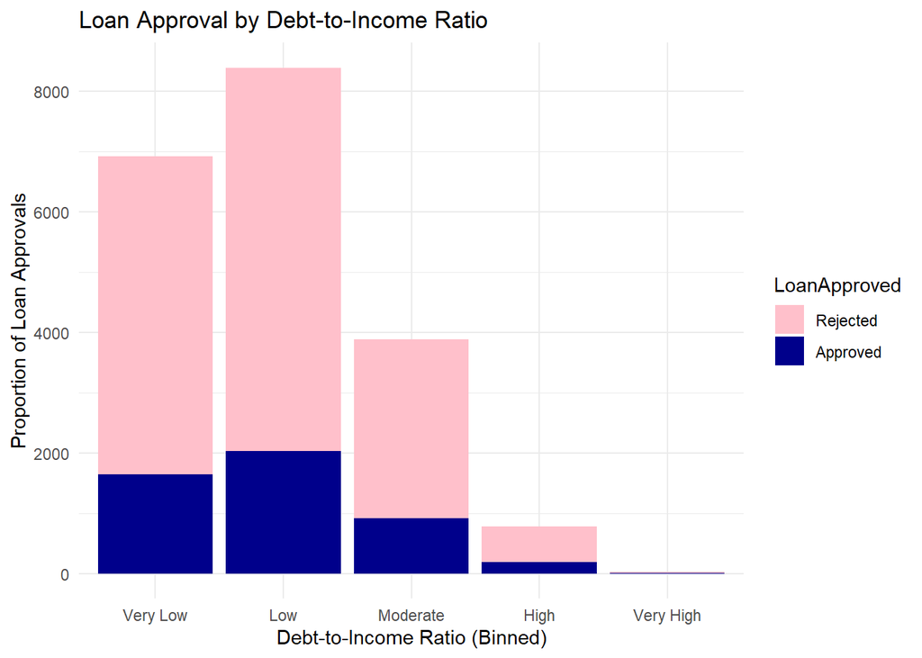

```r
# Create a new dataframe for analysis
df_analysis <- df

# Ensure LoanApproved in the new dataframe is labeled as "Rejected" and "Approved"
df_analysis$LoanApproved <- factor(df_analysis$LoanApproved, labels = c("Rejected", "Approved"))

# Bin Debt-to-Income Ratio for grouping in the new dataframe
df_analysis$DebtToIncomeBin <- cut(df_analysis$DebtToIncomeRatio,
                                   breaks = c(-Inf, 0.2, 0.4, 0.6, 0.8, Inf),
                                   labels = c("Very Low", "Low", "Moderate", "High", "Very High"))
# Analysis and Visualizations
## 1. Impact on Loan Approval
library(ggplot2)
ggplot(df_analysis, aes(x = DebtToIncomeBin, fill = LoanApproved)) +
  geom_bar() +
  labs(title = "Loan Approval by Debt-to-Income Ratio",
       x = "Debt-to-Income Ratio (Binned)",
       y = "Proportion of Loan Approvals") +
  theme_minimal() +
  scale_fill_manual(values = c("Rejected" = "pink", "Approved" = "darkblue"))
```

```r
cat("The debt-to-income ratio, as shown in the plot, does not appear to have much significance. Applicants with a low debt-to-income ratio have more loan rejections than approvals. \n")
```

```
## The debt-to-income ratio, as shown in the plot, does not appear to have much significance. Applicants with a low debt-to-income ratio have more loan rejections than approvals.
```

```r
cat("We are further using the logistic regression model to verify the significant relation between these variables\n")
```

```
## We are further using the logistic regression model to verify the significant relation between these variables
```

```r
# Model 1: Debt-to-Income Ratio vs Loan Approval
loan_approval_model <- glm(LoanApproved ~ DebtToIncomeRatio, data = df_analysis, family = "binomial")
approval_summary <- summary(loan_approval_model)
approval_coef <- approval_summary$coefficients[2, 1]
approval_p <- approval_summary$coefficients[2, 4]


# Loan Approval Proof
print(approval_summary)
```

```
##
## Call:
## glm(formula = LoanApproved ~ DebtToIncomeRatio, family = "binomial",
##     data = df_analysis)
##
## Coefficients:
##                    Estimate Std. Error z value Pr(>|z|)
## (Intercept)       -1.158313   0.033903   -34.2   <2e-16 ***
## DebtToIncomeRatio  0.000501   0.103492     0.0        1
## ---
## Signif. codes:  0 '***' 0.001 '**' 0.01 '*' 0.05 '.' 0.1 ' ' 1
##
## (Dispersion parameter for binomial family taken to be 1)
##
##     Null deviance: 21997  on 19999  degrees of freedom
## Residual deviance: 21997  on 19998  degrees of freedom
## AIC: 22001
##
## Number of Fisher Scoring iterations: 4
```

```r
if (approval_p < 0.05) {
  cat("Conclusion: Debt-to-Income Ratio negatively affects loan approval (coefficient =", round(approval_coef, 2),
      ", p =", round(approval_p, 5), "). Higher DTI reduces loan approval chances.\n")
} else {
  cat("Conclusion: Debt-to-Income Ratio does not significantly affect on loan approval,p-value associated with the coefficient(0.000501) is 1, which is much higher than 0.05.The Null deviance (21997) and Residual deviance (21997) are nearly identical and AIC (22001) value is also relatively high, which suggests that the model is not a particularly good fit.\n")
}
```

[output not shown]

Next, we will examine the impact of the debt-to-income ratio on interest rates.

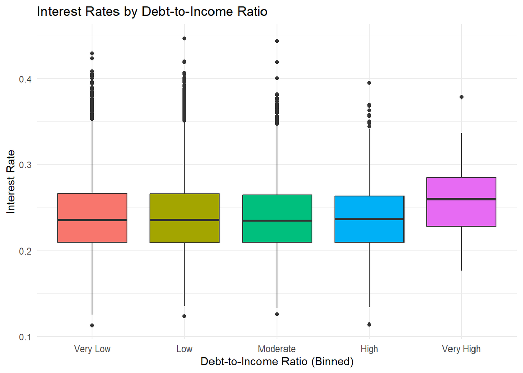

```r
## 2. Impact on Interest Rates
ggplot(df_analysis, aes(x = DebtToIncomeBin, y = InterestRate, fill = DebtToIncomeBin)) +
  geom_boxplot() +
  labs(title = "Interest Rates by Debt-to-Income Ratio",
       x = "Debt-to-Income Ratio (Binned)",
       y = "Interest Rate") +
  theme_minimal() +
  theme(legend.position = "none")
```

```r
cat("The plot shows no significant relationship between the debt-to-income ratio and interest rates. Only in cases of very high debt-to-income ratios is there a minimal change in interest rates, while there is no noticeable change for most other ratios.\n")
```

```
## The plot shows no significant relationship between the debt-to-income ratio and interest rates. Only in cases of very high debt-to-income ratios is there a minimal change in interest rates, while there is no noticeable change for most other ratios.
```

```r
cat("To verify this we are using the linear regression model to find the significant relation between these variables\n")
```

```
## To verify this we are using the linear regression model to find the significant relation between these variables
```

```r
# Model 2: Debt-to-Income Ratio vs Interest Rates
interest_rate_model <- lm(InterestRate ~ DebtToIncomeRatio, data = df_analysis)
interest_summary <- summary(interest_rate_model)
interest_coef <- interest_summary$coefficients[2, 1]
interest_p <- interest_summary$coefficients[2, 4]

print(interest_summary)
```

```
##
## Call:
## lm(formula = InterestRate ~ DebtToIncomeRatio, data = df_analysis)
##
## Residuals:
##      Min       1Q   Median       3Q      Max
## -0.12595 -0.02998 -0.00366  0.02638  0.20771
##
## Coefficients:
##                   Estimate Std. Error t value Pr(>|t|)
## (Intercept)        0.23957    0.00061  392.59   <2e-16 ***
## DebtToIncomeRatio -0.00161    0.00186   -0.86     0.39
## ---
## Signif. codes:  0 '***' 0.001 '**' 0.01 '*' 0.05 '.' 0.1 ' ' 1
##
## Residual standard error: 0.0422 on 19998 degrees of freedom
## Multiple R-squared:  3.73e-05,   Adjusted R-squared:  -1.27e-05
## F-statistic: 0.746 on 1 and 19998 DF,  p-value: 0.388
```

```r
if (interest_p < 0.05) {
  cat("Conclusion: Higher Debt-to-Income Ratio is associated with higher interest rates (coefficient =", round(interest_coef, 2),
      ", p =", round(interest_p, 5), ").\n")
} else {
  cat("Conclusion: The analysis reveals a very weak negative relationship between the debt-to-income ratio and interest rates, with a coefficient of -0.00161. However, the p-value of 0.39 indicates that this relationship is not statistically significant. While the intercept is highly significant, the model explains very little of the variation in interest rates, as reflected by the low R-squared value of 3.73e-05. Additionally, the F-statistic of 0.746 with a p-value of 0.388 suggests that the model does not significantly account for changes in interest rates.\n")
}
```

[output not shown]

Finally, we will examine the impact of the debt-to-income ratio on risk scores.

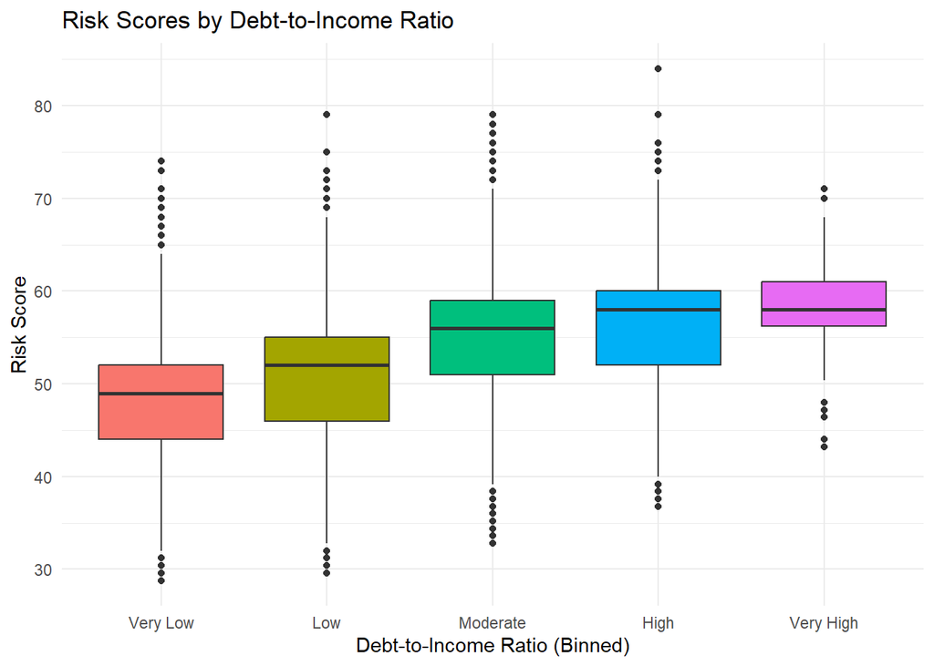

```r
## 3. Impact on Risk Scores
ggplot(df_analysis, aes(x = DebtToIncomeBin, y = RiskScore, fill = DebtToIncomeBin)) +
  geom_boxplot() +
  labs(title = "Risk Scores by Debt-to-Income Ratio",
       x = "Debt-to-Income Ratio (Binned)",
       y = "Risk Score") +
  theme_minimal() +
  theme(legend.position = "none")
```

```r
cat("The plot shows a significant relationship between the debt-to-income ratio and risk scores. As the debt-to-income ratio increases, the risk score also rises. This trend is evident in the box plot, where the median values of the risk scores increase from low to high debt-to-income ratios.\n")
```

```
## The plot shows a significant relationship between the debt-to-income ratio and risk scores. As the debt-to-income ratio increases, the risk score also rises. This trend is evident in the box plot, where the median values of the risk scores increase from low to high debt-to-income ratios.
```

```r
cat("To confirm if there is the significant relation between these variables we are using the linear regression model to verify.s\n")
```

```
## To confirm if there is the significant relation between these variables we are using the linear regression model to verify.s
```

```r
# Model 3: Debt-to-Income Ratio vs Risk Scores
risk_score_model <- lm(RiskScore ~ DebtToIncomeRatio, data = df_analysis)
risk_summary <- summary(risk_score_model)
risk_coef <- risk_summary$coefficients[2, 1]
risk_p <- risk_summary$coefficients[2, 4]

print(risk_summary)
```

```
##
## Call:
## lm(formula = RiskScore ~ DebtToIncomeRatio, data = df_analysis)
##
## Residuals:
##    Min     1Q Median     3Q    Max
## -21.56  -4.17   1.41   4.45  27.82
##
## Coefficients:
##                   Estimate Std. Error t value Pr(>|t|)
## (Intercept)         46.237      0.106   435.0   <2e-16 ***
## DebtToIncomeRatio   15.852      0.325    48.9   <2e-16 ***
## ---
## Signif. codes:  0 '***' 0.001 '**' 0.01 '*' 0.05 '.' 0.1 ' ' 1
##
## Residual standard error: 7.35 on 19998 degrees of freedom
## Multiple R-squared:  0.107,  Adjusted R-squared:  0.107
## F-statistic: 2.39e+03 on 1 and 19998 DF,  p-value: <2e-16
```

```r
if (risk_p < 0.05) {
  cat("Conclusion: Higher Debt-to-Income Ratio is associated with higher risk scores (coefficient =", round(risk_coef, 2),
      ", p =", round(risk_p, 5), ").\n")
} else {
  cat("Conclusion: The linear regression analysis reveals a significant positive relationship between the debt-to-income (DTI) ratio and risk scores. For each unit increase in the DTI ratio, the risk score increases by approximately 15.85 points with p-values less than 2e-16., indicating that higher DTI ratios are associated with higher risk scores. The model explains 10.7% of the variation in risk scores, as indicated by an R-squared value of 0.107. The F-statistic (2.39e+03) and a p-value of less than 2e-16 confirm that the model is highly significant.\n")
}
```

```
## Conclusion: Higher Debt-to-Income Ratio is associated with higher risk scores (coefficient = 15.8 , p = 0 ).
```

**Key Observations:**

The analysis indicates that the Debt-to-Income (DTI) ratio has no significant impact on loan approval or interest rates. The p-value for the DTI coefficient in loan approval is 1, well above the 0.05 threshold, and the Null and Residual deviance are nearly identical, suggesting a poor model fit. Similarly, the relationship between DTI and interest rates is weak, with a coefficient of -0.00161 and a p-value of 0.39, indicating no significant effect. However, a significant positive relationship is observed between DTI and risk scores, where each unit increase in DTI results in a 15.85-point increase in the risk score, explaining 10.7% of the variance.This implies that as risk scores, which may reflect financial instability, rise, there is a corresponding increase in the DTI ratio.